# RNA-seq in Bioconductor exercises

Tom Carroll

In todays session we will work with some of the RNA-seq data of adult mouse tissues from Bing Ren’s lab, Liver and Heart. - More information on liver data [can be found here](https://www.encodeproject.org/experiments/ENCSR000CHB/) - More information on heart data [can be found here](https://www.encodeproject.org/experiments/ENCSR000CGZ/) - More information on Kidney data [can be found here](https://www.encodeproject.org/experiments/ENCSR000CGZ/)

- Precounted RNAseq reads in genes for these tissues can be found as an R data object in **/Data/gC_TissueFull.RData**.

## DGE RNA-seq analysis.

1. Load the **/Data/gC_TissueFull.RData** and create a DESeq2 object. Create a venn diagram of genes upregulated in Kidney versus Liver and Heart.

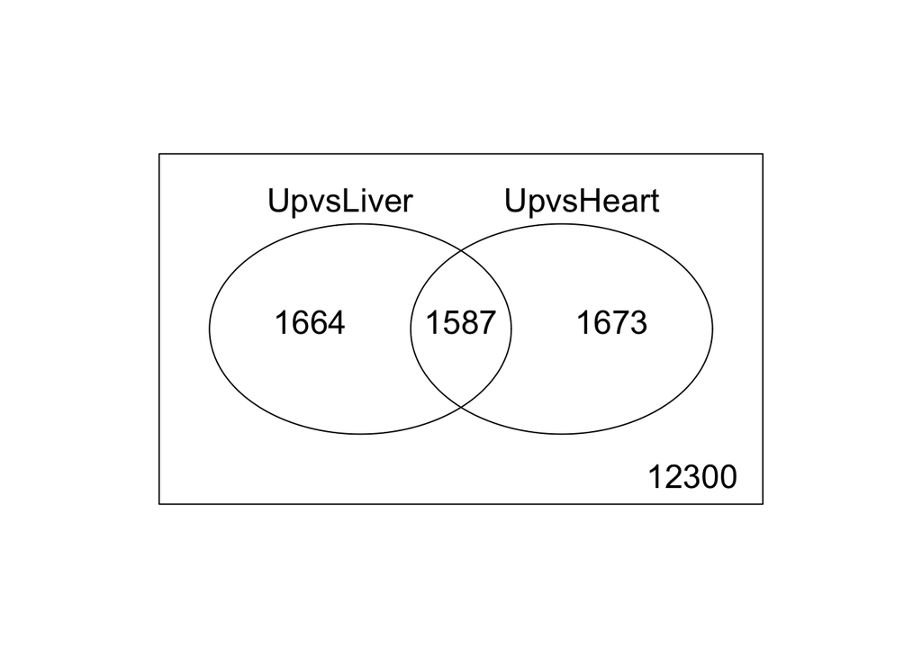

2. Perform a enrichment analysis for genes upregulated in Kidney vs both liver and Heart using KEGG pathways and plot the -log10 pvalue of the top 10 terms as a scatter plot.

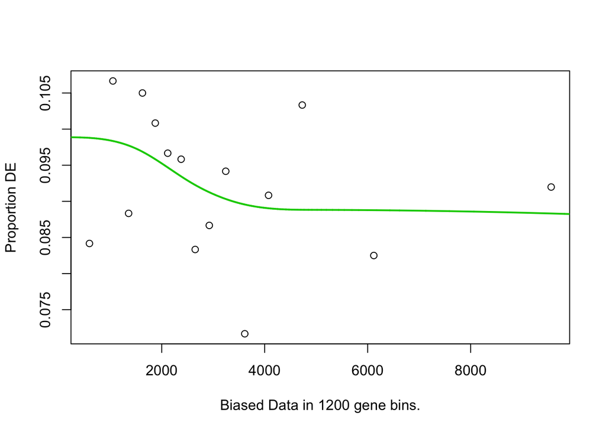

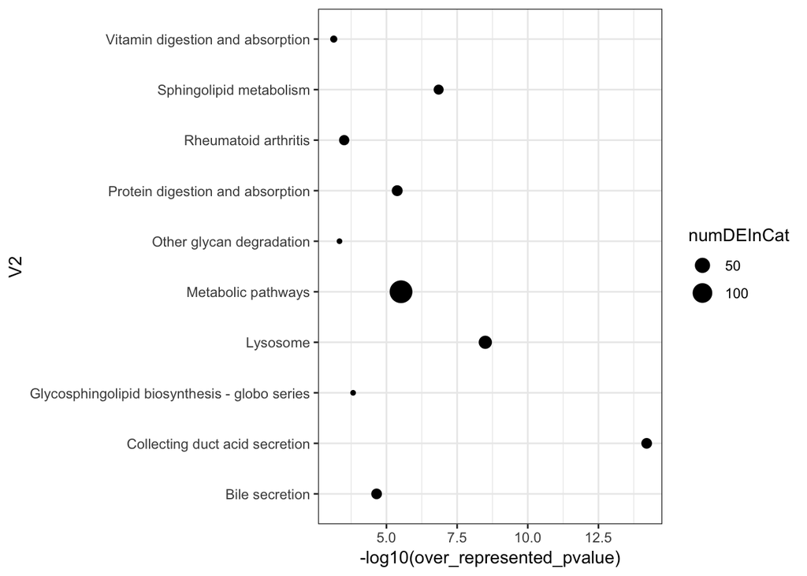

3. Create a boxplot plot of log2FC of genes (as from Kidney vs Liver and Kidney vs Heart comparison) in collecting duct acid secretion term vs all genes not in duct acid secretion term.

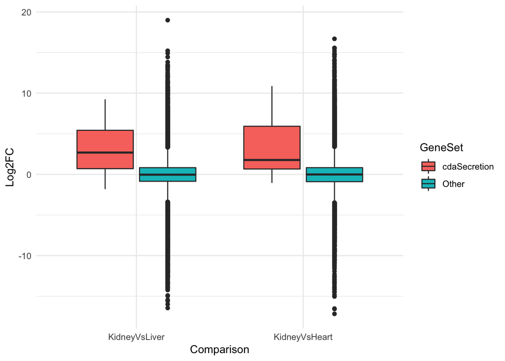

4. Identify genes changing significantly in any condition (< 0.05) and produce a file of results containing gene names.
5. DTU- Load the DEXseqResults object (found in **../Data/dxr_HeartVsLiver.RData**) and make a plot of the differnetial splicing for the Atp2a2 gene.

```
##       ENTREZID SYMBOL featureID exonBaseMean  dispersion     stat
## 10613    22003   Tpm1      E001     117.4021 0.009979611 790.0469
## 3297     12870     Cp      E026      72.2033 0.003310883 715.7727
## 2345     11938 Atp2a2      E002     651.1539 0.014388628 389.7594
##              pvalue          padj    Heart    Liver log2fold_Liver_Heart
## 10613 7.871657e-174 1.522772e-169 1.030876 3.134205             7.127092
## 3297  1.111406e-157 1.075007e-153 2.429502 1.079348            -4.605220
## 2345   9.338217e-87  6.021594e-83 2.146096 3.454840             4.357391
##       genomicData.seqnames genomicData.start genomicData.end
## 10613                 chr9          67022593        67023441
## 3297                  chr3          20008540        20009750
## 2345                  chr5         122455893       122457302
##       genomicData.width genomicData.strand countData.Sorted_Heart_1.bam
## 10613               849                  -                          174
## 3297               1211                  +                          156
## 2345               1410                  -                          985
##       countData.Sorted_Heart_2.bam countData.Sorted_Liver_1.bam
## 10613                          139                           80
## 3297                           112                           25
## 2345                           829                          505
##       countData.Sorted_Liver_2.bam  transcripts
## 10613                           97 uc009qfo....
## 3297                            21   uc008osc.2
## 2345                           403   uc008zlj.2
```

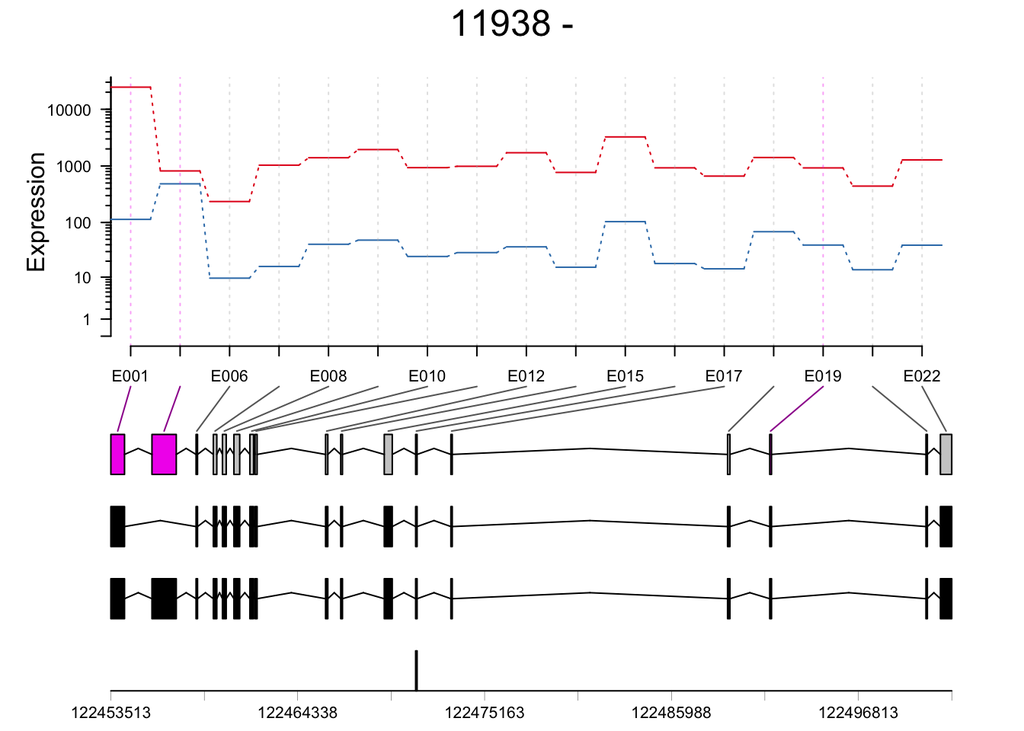

6. DTU- Load the RangedSummarizedExperiment object (found in **../Data/RSE_HeartAndLiver.RData** - obect is tissueExonCounts) and perform a differential exon analysis. Make a plot of the gene containing the most significantly differentially used exon.

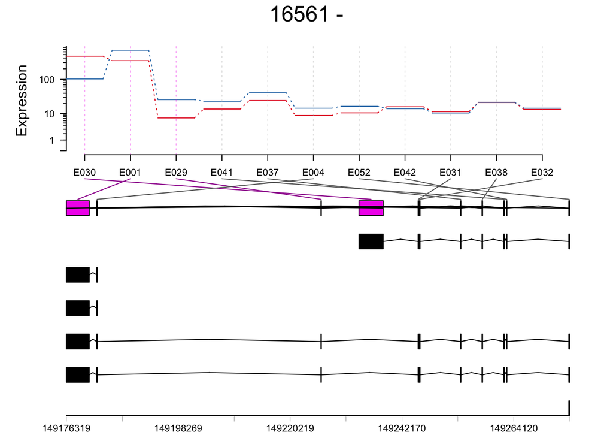